# World_Population_Analysis

**Global Population Dynamics: An Exploratory Data Analysis (1970–2022)**

**Introduction:-** The global population has experienced unprecedented growth and transformation over the past five decades, reshaping economies, societies, and the environment. Understanding how the world’s population evolves—its growth patterns, density distribution, and regional disparities—is crucial for planning sustainable development, managing resources, and forecasting future demographic challenges. This project conducts a detailed Exploratory Data Analysis (EDA) on global population data from 1970 to 2022, uncovering how continents and countries have changed over time in terms of population growth, density, and share of the world’s total population. Through this analysis, we aim to visualize long-term demographic shifts and extract meaningful insights that help explain how human population trends influence global dynamics.

**Business Problem:** Governments, policymakers, and global organizations such as the United Nations (UN) and World Bank rely on population data to make informed decisions about urban planning, healthcare, employment, and resource allocation. However, the raw population data across countries and decades is vast and often under-analyzed. Without effective data exploration, it becomes difficult to identify regions experiencing overpopulation pressure, aging challenges, or rapid urbanization. The lack of clear insights can lead to poor policy responses and inefficient economic planning. This project addresses that gap by transforming population statistics into actionable insights through detailed data visualization and analytical exploration.

**Problem Statement:-** Despite the availability of comprehensive global demographic data, there is limited accessible analysis that clearly explains how population, density, and growth rates vary across regions and over time. The problem lies in identifying:

1. Which continents and countries are contributing most to population growth?
2. LHow population density and growth rate correlate across regions?
3. What are the emerging demographic trends that may shape global development in the coming decades?

By applying exploratory data analysis techniques, this project aims to decode population trends from 1970 to 2022, making the information understandable, visual, and valuable for decision-making and research.

**Objectives**

1. To analyze global population growth patterns from 1970 to 2022.
2. To compare population density and growth rate across continents and countries.
3. To identify the top and least populated regions in 2022.
4. To examine relationships between area, density, and growth rate.
5. To derive actionable insights and highlight key demographic transitions through data visualization.

**Goal:-** The goal of this project is to perform a comprehensive exploratory data analysis on world population data, revealing the patterns, relationships, and shifts that define humanity’s demographic journey. By transforming raw statistical data into visual narratives, this project enables a clearer understanding of how the population has evolved globally — empowering better planning, forecasting, and strategic decision-making for future generations.

```python
# #Importing core data libraries
import pandas as pd
import numpy as np

# Importing visualization libraries
import matplotlib.pyplot as plt
import seaborn as sns
import plotly.express as px
```

```python
# Load the dataset
df = pd.read_csv('/content/world_population.csv')
print(" Data loaded successfully!")
print(f"Total Rows: {df.shape[0]}, Total Columns: {df.shape[1]}")
df.head()
```

```
 Data loaded successfully!
Total Rows: 234, Total Columns: 17
```

|  | Rank | CCA3 | Country/Territory | Capital | Continent | 2022 Population | 2020 Population | 2015 Population | 2010 Population | 2000 Population | 1990 Population | 1980 Population | 1970 Population | Area (km²) | Density (per km²) | Growth Rate | World Population Percentage |
| --- | --- | --- | --- | --- | --- | --- | --- | --- | --- | --- | --- | --- | --- | --- | --- | --- | --- |
| 0 | 36 | AFG | Afghanistan | Kabul | Asia | 41128771 | 38972230 | 33753499 | 28189672 | 19542982 | 10694796 | 12486631 | 10752971 | 652230 | 63.0587 | 1.0257 | 0.52 |
| 1 | 138 | ALB | Albania | Tirana | Europe | 2842321 | 2866849 | 2882481 | 2913399 | 3182021 | 3295066 | 2941651 | 2324731 | 28748 | 98.8702 | 0.9957 | 0.04 |
| 2 | 34 | DZA | Algeria | Algiers | Africa | 44903225 | 43451666 | 39543154 | 35856344 | 30774621 | 25518074 | 18739378 | 13795915 | 2381741 | 18.8531 | 1.0164 | 0.56 |
| 3 | 213 | ASM | American Samoa | Pago Pago | Oceania | 44273 | 46189 | 51368 | 54849 | 58230 | 47818 | 32886 | 27075 | 199 | 222.4774 | 0.9831 | 0.00 |
| 4 | 203 | AND | Andorra | Andorra la Vella | Europe | 79824 | 77700 | 71746 | 71519 | 66097 | 53569 | 35611 | 19860 | 468 | 170.5641 | 1.0100 | 0.00 |

```python
# Check dataset structure — column types, non-null counts, memory usage
print("\n Dataset Information:")
df.info()
```

```
 Dataset Information:
<class 'pandas.core.frame.DataFrame'>
RangeIndex: 234 entries, 0 to 233
Data columns (total 17 columns):
 #   Column                       Non-Null Count  Dtype
---  ------                       --------------  -----
 0   Rank                         234 non-null    int64
 1   CCA3                         234 non-null    object
 2   Country/Territory            234 non-null    object
 3   Capital                      234 non-null    object
 4   Continent                    234 non-null    object
 5   2022 Population              234 non-null    int64
 6   2020 Population              234 non-null    int64
 7   2015 Population              234 non-null    int64
 8   2010 Population              234 non-null    int64
 9   2000 Population              234 non-null    int64
 10  1990 Population              234 non-null    int64
 11  1980 Population              234 non-null    int64
 12  1970 Population              234 non-null    int64
 13  Area (km²)                   234 non-null    int64
 14  Density (per km²)            234 non-null    float64
 15  Growth Rate                  234 non-null    float64
 16  World Population Percentage  234 non-null    float64
dtypes: float64(3), int64(10), object(4)
memory usage: 31.2+ KB
```

```python
# Summary statistics for numerical columns.
print("\n Statistical Summary:")
display(df.describe().T)
```

```
 Statistical Summary:
```

|  | count | mean | std | min | 25% | 50% | 75% | max |
| --- | --- | --- | --- | --- | --- | --- | --- | --- |
| Rank | 234.0 | 1.175000e+02 | 6.769417e+01 | 1.0000 | 59.250000 | 1.175000e+02 | 1.757500e+02 | 2.340000e+02 |
| 2022 Population | 234.0 | 3.407441e+07 | 1.367664e+08 | 510.0000 | 419738.500000 | 5.559944e+06 | 2.247650e+07 | 1.425887e+09 |
| 2020 Population | 234.0 | 3.350107e+07 | 1.355899e+08 | 520.0000 | 415284.500000 | 5.493074e+06 | 2.144798e+07 | 1.424930e+09 |
| 2015 Population | 234.0 | 3.172996e+07 | 1.304050e+08 | 564.0000 | 404676.000000 | 5.307400e+06 | 1.973085e+07 | 1.393715e+09 |
| 2010 Population | 234.0 | 2.984524e+07 | 1.242185e+08 | 596.0000 | 393149.000000 | 4.942770e+06 | 1.915957e+07 | 1.348191e+09 |
| 2000 Population | 234.0 | 2.626947e+07 | 1.116982e+08 | 651.0000 | 327242.000000 | 4.292907e+06 | 1.576230e+07 | 1.264099e+09 |
| 1990 Population | 234.0 | 2.271022e+07 | 9.783217e+07 | 700.0000 | 264115.750000 | 3.825410e+06 | 1.186923e+07 | 1.153704e+09 |
| 1980 Population | 234.0 | 1.898462e+07 | 8.178519e+07 | 733.0000 | 229614.250000 | 3.141146e+06 | 9.826054e+06 | 9.823725e+08 |
| 1970 Population | 234.0 | 1.578691e+07 | 6.779509e+07 | 752.0000 | 155997.000000 | 2.604830e+06 | 8.817329e+06 | 8.225344e+08 |
| Area (km²) | 234.0 | 5.814494e+05 | 1.761841e+06 | 1.0000 | 2650.000000 | 8.119950e+04 | 4.304258e+05 | 1.709824e+07 |
| Density (per km²) | 234.0 | 4.521270e+02 | 2.066122e+03 | 0.0261 | 38.417875 | 9.534675e+01 | 2.389332e+02 | 2.317227e+04 |
| Growth Rate | 234.0 | 1.009577e+00 | 1.338498e-02 | 0.9120 | 1.001775 | 1.007900e+00 | 1.016950e+00 | 1.069100e+00 |
| World Population Percentage | 234.0 | 4.270513e-01 | 1.714977e+00 | 0.0000 | 0.010000 | 7.000000e-02 | 2.800000e-01 | 1.788000e+01 |

```python
# Check for missing values
print("\n Missing Values Count:")
display(df.isnull().sum())
```

```
 Missing Values Count:
```

|  | 0 |
| --- | --- |
| Rank | 0 |
| CCA3 | 0 |
| Country/Territory | 0 |
| Capital | 0 |
| Continent | 0 |
| 2022 Population | 0 |
| 2020 Population | 0 |
| 2015 Population | 0 |
| 2010 Population | 0 |
| 2000 Population | 0 |
| 1990 Population | 0 |
| 1980 Population | 0 |
| 1970 Population | 0 |
| Area (km²) | 0 |
| Density (per km²) | 0 |
| Growth Rate | 0 |
| World Population Percentage | 0 |

**dtype:** int64

```python
# Quick check for duplicate rows
duplicate_count = df.duplicated().sum()
print(f"\n Duplicate Rows Found: {duplicate_count}")

# Optionally show the duplicate rows (first 10) if any
if duplicate_count > 0:
    display(df[df.duplicated(keep=False)].head(10))
```

```
 Duplicate Rows Found: 0
```

```python
# Rename columns for easy handling
df.columns = ['Rank','Code','Country','Capital','Continent','Pop_2022','Pop_2020','Pop_2015',
              'Pop_2010','Pop_2000','Pop_1990','Pop_1980','Pop_1970','Area_km2',
              'Density_per_km2','Growth_Rate','World_Pop_Pct']
```

```python
# Convert population and numeric fields to integers/floats if needed:
num_cols = ['Pop_2022','Pop_2020','Pop_2015','Pop_2010','Pop_2000','Pop_1990',
            'Pop_1980','Pop_1970','Area_km2','Density_per_km2','Growth_Rate','World_Pop_Pct']
df[num_cols] = df[num_cols].apply(pd.to_numeric, errors='coerce')
```

```python
# Create a “long format” version for time-series plots
df_melted = df.melt(
    id_vars=['Country', 'Continent', 'Area_km2'],
    value_vars=['Pop_1970', 'Pop_1980', 'Pop_1990', 'Pop_2000', 'Pop_2010', 'Pop_2015', 'Pop_2020', 'Pop_2022'],
    var_name='Year',
    value_name='Population'
)

# Extract year numbers correctly (fixes the warning)
df_melted['Year'] = df_melted['Year'].str.extract(r'(\d+)').astype(int)
```

**Business Question 1:-** Which continents have experienced the highest and lowest population growth from 1970 to 2022, and what strategic implications does this have for global development and resource planning?

**Solution:-** From 1970 to 2022, Asia experienced the highest population growth, followed by rapidly rising Africa, while Europe and North America showed slow or stagnant growth. This indicates that Asia and Africa need strong policies for sustainable urbanization and resource management, while Europe and North America must address aging populations and labor shortages.

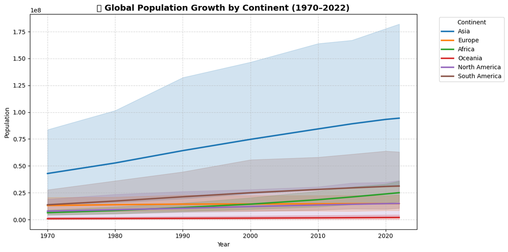

```python
# A. Global Population Growth (1970–2022)
plt.figure(figsize=(12, 6))
sns.lineplot(data=df_melted, x='Year', y='Population', hue='Continent', linewidth=2.5)
plt.title(' Global Population Growth by Continent (1970–2022)', fontsize=14, weight='bold')
plt.xlabel('Year')
plt.ylabel('Population')
plt.legend(title='Continent', bbox_to_anchor=(1.05, 1), loc='upper left')
plt.grid(True, linestyle='--', alpha=0.5)
plt.tight_layout()
plt.show()
```

**Business Question 2:-** Which continents hold the largest share of the global population in 2022, and what does this reveal about global population concentration and regional development priorities?

**Solution:-** In 2022, Asia holds the largest share of the global population, followed by Africa and Europe. This shows that the world’s population is heavily concentrated in Asia, emphasizing its critical role in global markets, labor supply, and resource consumption. The rapid growth in Africa suggests emerging opportunities but also challenges in infrastructure, healthcare, and education. Meanwhile, Europe, Oceania, and North America have smaller shares, indicating more stabilized or aging populations.

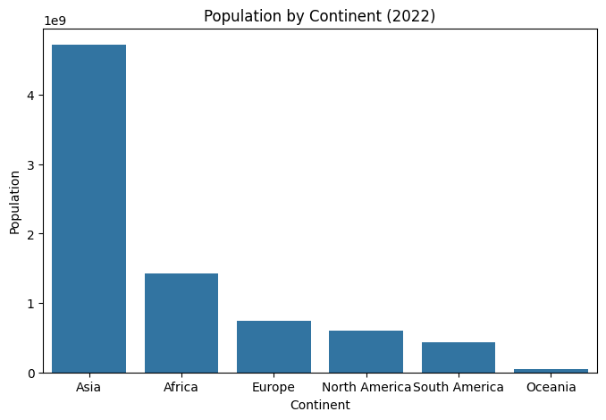

```python
# Continent-Wise Population Distribution
continent_pop = df.groupby('Continent')['Pop_2022'].sum().sort_values(ascending=False)
plt.figure(figsize=(8,5))
sns.barplot(x=continent_pop.index, y=continent_pop.values)
plt.title('Population by Continent (2022)')
plt.ylabel('Population')
plt.show()
```

**Business Question 3:-** Which countries have the highest population in 2022, and how does this distribution impact global economic and resource dynamics?

**Solution:-** In 2022, China and India lead as the two most populous countries, followed by the United States, Indonesia, and Pakistan. These nations together account for a major portion of the global population, giving them significant influence over global markets, labor forces, and resource demand. The dominance of Asian countries highlights the region’s role as a population and economic powerhouse, while countries with smaller populations may focus on innovation, productivity, and sustainable resource use to balance global competitiveness.

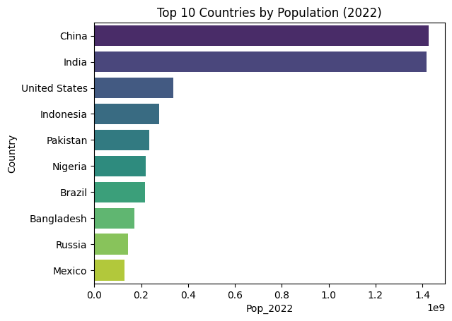

```python
# Top 10 Most Populous Countries (2022)
top10 = df.nlargest(10, 'Pop_2022')[['Country','Pop_2022']]
sns.barplot(x='Pop_2022', y='Country', data=top10, palette='viridis')
plt.title('Top 10 Countries by Population (2022)')
```

**Business Question 4:-** Which countries are experiencing the highest and lowest population growth rates globally, and what are the implications for their economic and social development?

**Solution:-** The choropleth map reveals that African countries have the highest population growth rates, indicating expanding young populations and potential for future workforce growth — but also rising challenges in education, healthcare, and job creation. In contrast, many European and East Asian countries show low or even negative growth rates, signaling aging populations and possible labor shortages in the near future. This uneven growth highlights the need for targeted policies — developing nations must manage rapid expansion sustainably, while developed regions should focus on innovation and migration strategies to balance demographic decline.

```python
# Growth Rate Analysis — World Choropleth Map
fig = px.choropleth(
    df,
    locations='Country',
    locationmode='country names',
    color='Growth_Rate',
    hover_name='Country',
    color_continuous_scale='Viridis',
    title=' Global Population Growth Rate (by Country)',
    template='plotly_white'
)
fig.update_layout(
    geo=dict(showframe=False, showcoastlines=True, projection_type='natural earth')
)
fig.show()
```

[interactive chart not shown]

**Business Question 4:-** Which countries have the highest population density in 2022, and what challenges or opportunities does this create for urban planning and resource management?

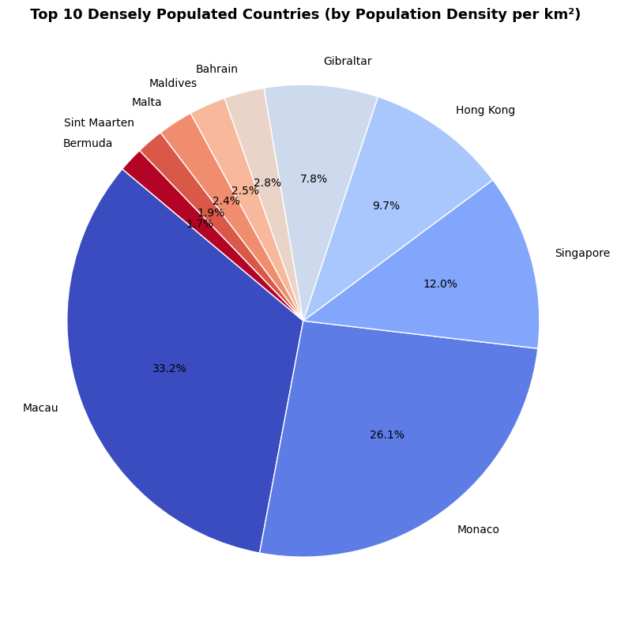

```python
# Top 10 most densely populated countries
densest = df.nlargest(10, 'Density_per_km2')[['Country', 'Density_per_km2']]

# Create pie chart
plt.figure(figsize=(8, 8))
plt.pie(
    densest['Density_per_km2'],
    labels=densest['Country'],
    autopct='%1.1f%%',
    startangle=140,
    colors=plt.cm.coolwarm(np.linspace(0, 1, len(densest))),
    wedgeprops={'edgecolor': 'white'}
)

plt.title(' Top 10 Densely Populated Countries (by Population Density per km²)', fontsize=13, fontweight='bold')
plt.tight_layout()
plt.show()
```

**Business Question 5:-** How are key demographic factors such as population size, area, density, and growth rate correlated, and what insights can be drawn for population planning and resource allocation?

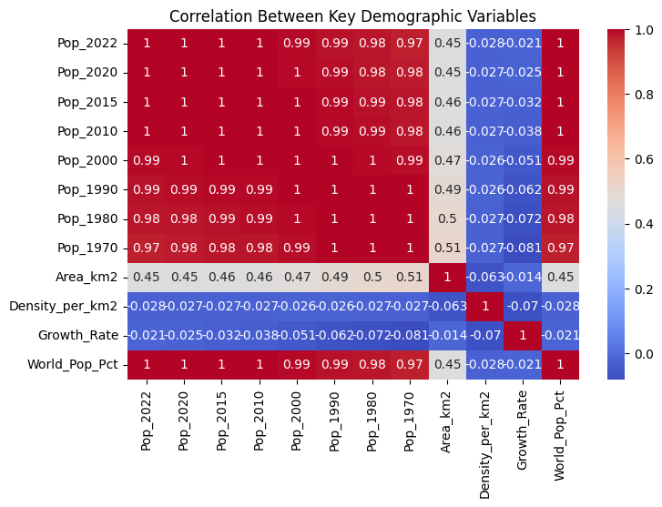

```python
# Correlation Heatmap
plt.figure(figsize=(8,5))
sns.heatmap(df[num_cols].corr(), annot=True, cmap='coolwarm')
plt.title('Correlation Between Key Demographic Variables')
```

**Business Question 6:-** How has population growth trended across different continents from 1970 to 2022, and what does this reveal about global demographic shifts?

**Solution:-** The line chart shows that Asia has maintained the largest population throughout the decades, while Africa exhibits the fastest growth rate, especially after 2000. Europe and North America show slower, stabilized growth, reflecting aging populations and lower fertility rates. This trend indicates a global demographic shift toward Africa and Asia, where younger populations are driving expansion — signaling future centers of labor force, consumption, and economic opportunity, but also highlighting the need for sustainable development planning in these rapidly growing regions.

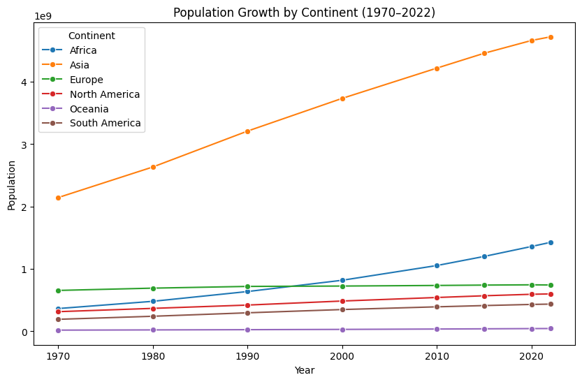

```python
# Population Growth Over Decades (Trend by Continent)
continent_trend = df_melted.groupby(['Year','Continent'])['Population'].sum().reset_index()
plt.figure(figsize=(10,6))
sns.lineplot(data=continent_trend, x='Year', y='Population', hue='Continent', marker='o')
plt.title('Population Growth by Continent (1970–2022)')
```

**Business Question 7:-** Which countries contribute the most to the world’s total population in 2022, and what does this concentration mean for global influence and resource demand?

**Solution:-** The donut chart shows that a small number of countries—primarily China, India, United States, Indonesia, and Pakistan—contribute a major share of the world’s total population. This heavy concentration means that these nations hold significant economic, political, and environmental influence globally. Their large populations drive global consumption, labor markets, and urbanization trends, while also increasing pressure on natural resources and sustainability efforts. This insight highlights the importance of balanced global policies that consider both the opportunities and challenges arising from population concentration in a few key nations.

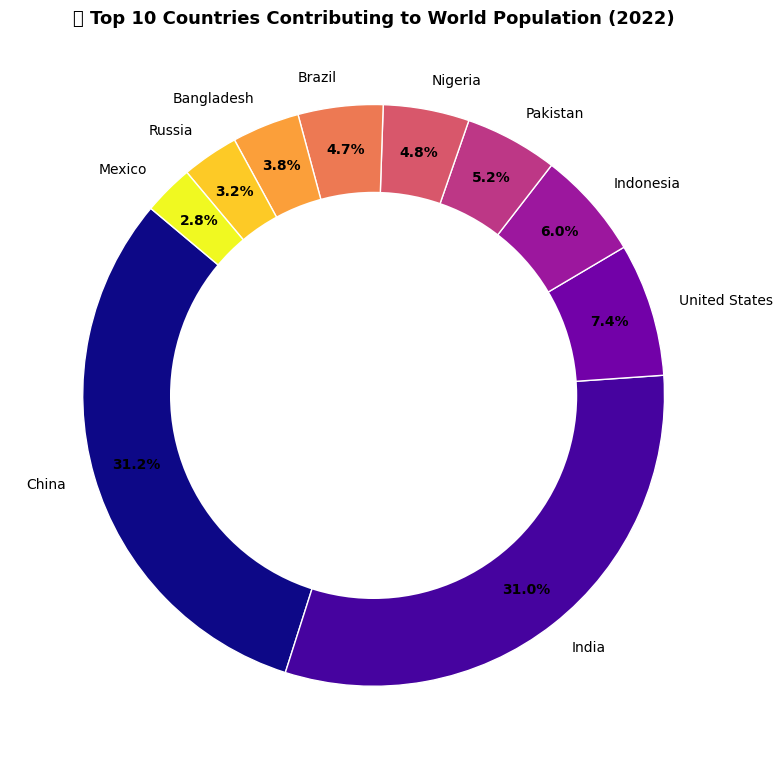

```python
# World Population Percentage
top10_pct = df.nlargest(10, 'World_Pop_Pct')[['Country', 'World_Pop_Pct']]

# Plot a donut chart
fig, ax = plt.subplots(figsize=(8, 8))
wedges, texts, autotexts = ax.pie(
    top10_pct['World_Pop_Pct'],
    labels=top10_pct['Country'],
    autopct='%1.1f%%',
    startangle=140,
    pctdistance=0.85,
    colors=plt.cm.plasma(np.linspace(0, 1, len(top10_pct))),
    wedgeprops={'edgecolor': 'white'}
)

# Create donut hole
centre_circle = plt.Circle((0, 0), 0.70, fc='white')
fig.gca().add_artist(centre_circle)

# Styling
plt.title(' Top 10 Countries Contributing to World Population (2022)', fontsize=13, fontweight='bold')
plt.setp(autotexts, size=10, weight='bold', color='black')
plt.tight_layout()
plt.show()
```

```python
# Country-Level Analysis — Population Growth (1970–2022)
import plotly.express as px

# Select key countries for comparison
countries = ['India', 'China', 'USA', 'Nigeria', 'Japan']

# Filter data
country_data = df_melted[df_melted['Country'].isin(countries)]

# Create interactive line chart
fig = px.line(
    country_data,
    x='Year',
    y='Population',
    color='Country',
    markers=True,
    line_shape='spline',
    title=' Population Growth (1970–2022): India, China, USA, Nigeria & Japan',
    template='plotly_white'
)

# Customize hover info and axes
fig.update_traces(
    hovertemplate='<b>%{fullData.name}</b><br>Year: %{x}<br>Population: %{y:,.0f}'
)

fig.update_layout(
    title_font=dict(size=18, family='Arial', color='black'),
    legend_title_text='Country',
    xaxis_title='Year',
    yaxis_title='Population',
    xaxis=dict(showgrid=True, gridwidth=0.5, gridcolor='lightgrey'),
    yaxis=dict(showgrid=True, gridwidth=0.5, gridcolor='lightgrey'),
    legend=dict(
        bgcolor='rgba(255,255,255,0.8)',
        bordercolor='lightgrey',
        borderwidth=1
    )
)

# Display the chart
fig.show()
```

[interactive chart not shown]

**Conclusion:**

The World Population Analysis (1970–2022) project offers valuable insights into how the global population has evolved over five decades. The analysis reveals that Asia remains the world’s most populous and economically influential region, driven by India and China, while Africa is emerging as the next major growth center with rapid demographic expansion. In contrast, Europe, Japan, and parts of North America face stagnating or declining populations, indicating aging societies and shrinking workforces.

Overall, this analysis shows a world undergoing significant demographic shifts — from East Asia toward South Asia and Africa. These changes carry profound implications for economic growth, sustainability, and policy planning. Understanding population dynamics through data-driven analysis is essential for shaping a more balanced and sustainable global future.